# Palmer Penguins Dataset - Practice Analysis (EDA)

Shefali C.

## About the data:

- The Palmer Penguins dataset is pre-loaded in Rstudio.This dataset was prepared by Dr. Kristen Gormon.
- Our penguins belong to 3 islands- *Dream*, *Biscoe*, *Torgersen*.
- They belong to 3 species- *Gentoo*, *Chinstrip*, *Adelie*.
- Data has been collected for 3 years- 2007, 2008 and 2009.
- It contains the body measurements of these penguins: *flipper length (in mm)*, *body mass (in grams)*, *bill length (in mm)*, *bill depth (in mm)*.

## Why did I analyse this data?

Just for practice!

## Environment Setup

Setting up my environment by loading all relevant packages- `tidyverse`,`ggplot2` (for visualization) & `palmerpenguins` dataset.

The dataset contains some missing values which will be omitted before usage.

A basic theme that will be applied to all the plots has been stored in a variable. All other components of theme layout specific to a particular plot will be added as another layer on this basic layer.

### 1. From 2007 to 2009, which penguin species accounted for highest population in the 3 islands?

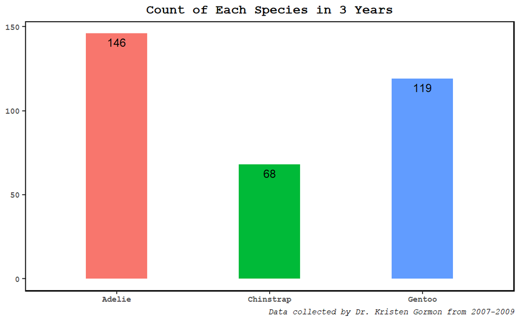

```r
ggplot(data = clean_penguins_data,aes(x = species, fill =species)) +
  geom_bar(width = 0.4) +
  geom_text(aes(label=..count..), vjust = 1.5,stat = "count", color = "black") +
  labs(title = "Count of Each Species in 3 Years", caption = caption_line, y = "Count of each species") +
  plot_theme +
  theme(legend.position = "none") +
  labels_theme
```

**Adelie** species of penguins account for highest population on all 3 islands combined, followed by **Gentoo** and then **Chinstrap**.

### 2. Do penguin species co-habitate? Which species accounts for highest population on each island?

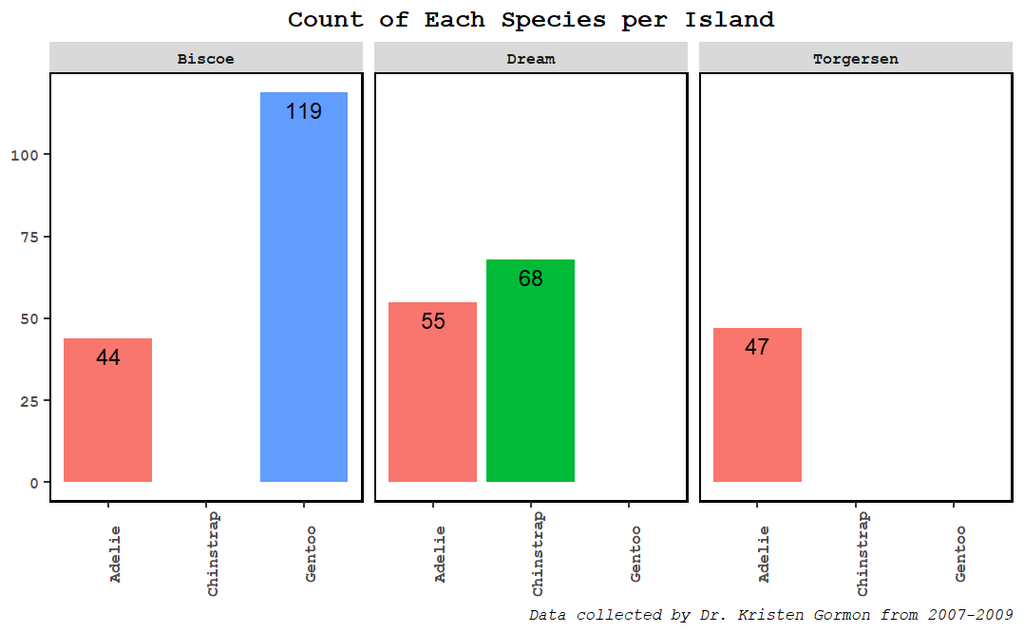

```r
ggplot(data = clean_penguins_data,aes(x = species, fill = species)) +
  geom_bar() +
  geom_text(aes(label = ..count..),vjust = 1.5,stat = "count",color = "black")+
  labs(title = "Count of Each Species per Island", caption = caption_line) +
  facet_wrap(~island) + plot_theme +  labels_theme +
  theme(axis.text.x = element_text(angle = 90),legend.position = "none")
```

Yes!

- **Biscoe Island**- Both *Adelie* and *Gentoo* species found on this island.
- **Dream**- *Adelie* and *Chinstrap* penguins are found on this island.
- **Torgersen**- Sadly, only **Adelie** penguins live on this island. :(

### 3. Population of male and female penguins per year.

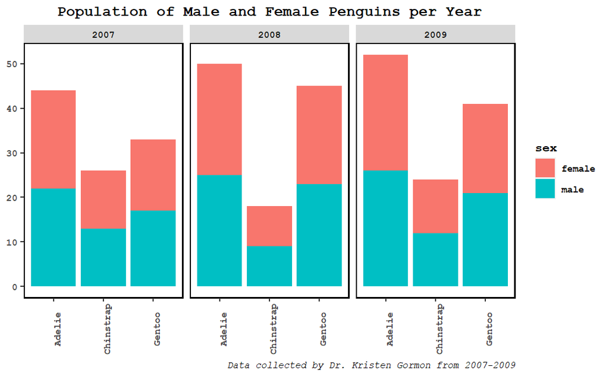

```r
ggplot(data = clean_penguins_data,aes(x = species, fill = sex)) +
  geom_bar() +
  labs(title = "Population of Male and Female Penguins per Year", caption=caption_line, x="penguin species", y="total count")+
  plot_theme + labels_theme +
  theme(axis.text.x = element_text(angle=90))+
  facet_wrap(~year)
```

Well, the gender ratio seems balanced among these folks (in this data, of course. :|)

```r
penguins_stats <- clean_penguins_data %>%
  group_by(species) %>%
  drop_na() %>%
  summarize(avg_bill_length = mean(bill_length_mm,2), avg_bill_depth = mean(bill_depth_mm,2),
            avg_flipper_length = mean(flipper_length_mm,2), avg_body_mass = mean(body_mass_g,2))
```

##### The stats are as follows:

```r
head(penguins_stats)
```

| species | avg_bill_length | avg_bill_depth | avg_flipper_length | avg_body_mass |
| --- | --- | --- | --- | --- |
| Adelie | 38.85 | 18.40 | 190 | 3700 |
| Chinstrap | 49.55 | 18.45 | 196 | 3700 |
| Gentoo | 47.40 | 15.00 | 216 | 5050 |

### Average bill length of each species.

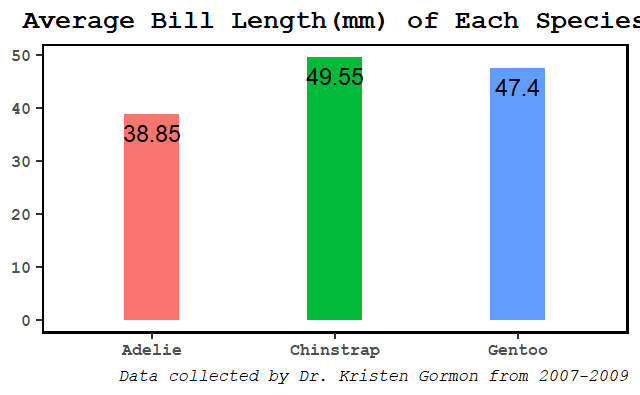

```r
ggplot(data = penguins_stats,aes(x=species, y=avg_bill_length, fill=species)) +
  geom_bar(stat = "identity",width=0.3)+
  geom_text(aes(label=avg_bill_length), vjust = 1.5,stat = "identity", color = "black") +
  labs(title = "Average Bill Length(mm) of Each Species",caption = caption_line,
       y = "average bill length(mm)")+
  plot_theme + labels_theme +
  theme(legend.position = "none")
```

**Chinstrap** penguins have the longest beak on an average, followed by **Gentoo** and then **Adelie**.

### Average bill depth of each species.

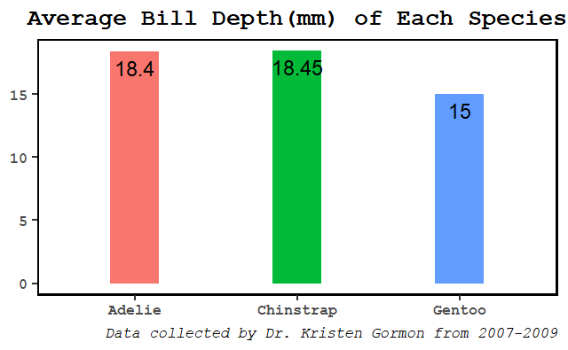

```r
ggplot(data = penguins_stats, aes(x=species,y=avg_bill_depth,fill=species))+
  geom_bar(stat = "identity",width = 0.3)+
  geom_text(aes(label=avg_bill_depth), vjust = 1.5,stat = "identity", color = "black") +
  labs(title = "Average Bill Depth(mm) of Each Species", caption = caption_line,
       y = "average bill depth(mm)")+
  plot_theme + labels_theme +
  theme(legend.position = "none")
```

### Average flipper length of each species

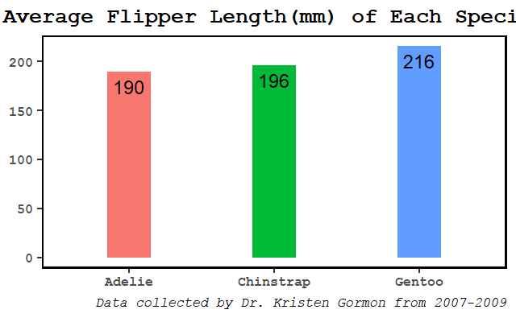

```r
ggplot(data=penguins_stats, aes(x=species,y=avg_flipper_length,fill=species))+
  geom_bar(stat = "identity",width = 0.3)+
  geom_text(aes(label=avg_flipper_length), vjust = 1.5,stat = "identity", color = "black")+
  labs(title="Average Flipper Length(mm) of Each Species",caption = caption_line,
       y = "average flipper length(mm)")+
  plot_theme + labels_theme +
  theme(legend.position = "none")
```

### Average body mass of each species

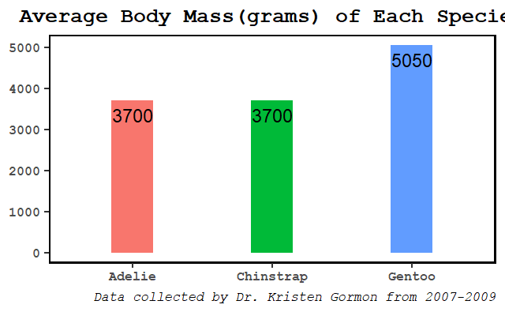

```r
ggplot(data = penguins_stats, aes(x=species,y=avg_body_mass,fill=species))+
  geom_bar(stat = "identity",width = 0.3)+
  geom_text(aes(label=avg_body_mass), vjust = 1.5,stat = "identity", color = "black")+
  labs(title = "Average Body Mass(grams) of Each Species",caption=caption_line,
       y = "average body mass(grams)")+
  plot_theme + labels_theme +
  theme(legend.position = "none")
```

##### gender_count stores the male and female population of each species per island.

```r
gender_count <- clean_penguins_data %>%
  group_by(species,island) %>%
  drop_na() %>%
  summarize(male = sum(sex == 'male'), female = sum(sex=='female'))
```

##### A quick peak into the wide-form of gender_count aggregation.

| species | island | male | female |
| --- | --- | --- | --- |
| Adelie | Biscoe | 22 | 22 |
| Adelie | Dream | 28 | 27 |
| Adelie | Torgersen | 23 | 24 |
| Chinstrap | Dream | 34 | 34 |
| Gentoo | Biscoe | 61 | 58 |

##### gender_count_long_form is just the same aggregation as earlier, converted to long format.

```r
gender_count_long_form <- pivot_longer(gender_count, cols = c(male,female),names_to = "gender",values_to = "total_count")
```

#### A quick peak into the long-form of the same data.

```r
head(gender_count_long_form)
```

| species | island | gender | total_count |
| --- | --- | --- | --- |
| Adelie | Biscoe | male | 22 |
| Adelie | Biscoe | female | 22 |
| Adelie | Dream | male | 28 |
| Adelie | Dream | female | 27 |
| Adelie | Torgersen | male | 23 |
| Adelie | Torgersen | female | 24 |

The gender_count data was converted from wide format to long format in order to plot male and female population of each species side by side and not as a stacked bar chart.

### Plotting male and female count of each species separately.

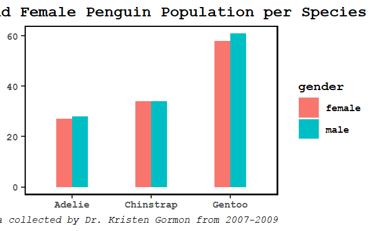

```r
ggplot(data = gender_count_long_form, aes(x=species,y=total_count,fill=gender))+
  geom_bar(stat = "identity",width = 0.4,position = "dodge")+
  labs(title="Male and Female Penguin Population per Species",caption = caption_line, x="penguin species", y="total count")+
  plot_theme + labels_theme
```

The male to female ration is pretty much balanced among the 3 species of penguins here.

### Plotting male and female population per species per island.

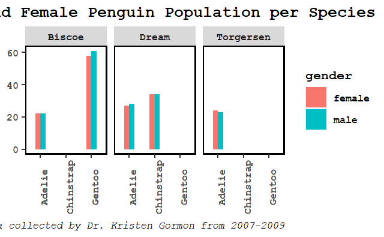

```r
ggplot(data = gender_count_long_form, aes(x=species,y=total_count,fill=gender))+
  geom_bar(stat = "identity",width = 0.4,position = "dodge")+
  labs(title="Male and Female Penguin Population per Species",caption = caption_line, x="penguin species", y="total count")+
  plot_theme + labels_theme + facet_wrap(~island) +
  theme(axis.text.x = element_text(angle = 90))
```

Lastly, this is the viz for male to female population of each species on each island.

###### THE END (for now :))